# Safety Plan Peace 2024

Al Irvine

Al Irvine  
New Graph Environment Ltd.  
al@newgraphenvironment  
250-777-1518  
Date Original: 2024-08-09  
Date Revised: 2024-09-08

# Safety Plan - 2024-073-sern-peace-fish-passage

The latest version of this pdf can be downloaded [here](https://github.com/NewGraphEnvironment/safety_plan_peace_2024/raw/main/docs/safety_plan_sern-peace-fish-passage.pdf).

Georeferenced pdf maps can be accessed and downloaded [here](https://hillcrestgeo.ca/outgoing/fishpassage/projects/parsnip/).

## New Graph Employee Information

Al Irvine  
Vehicle: 2013 Toyota Tundra black w/flatdeck and yellow can-am quad  
Accommodation: 3396 Rosia Road, Prince George, BC V2K 4Y5

Lucy Schick  
Vehicle: 2006 Pontiac Vibe red  
Accommodation: 6596 Dawson Road, Prince George, BC V2K 5Y4

## Crew Members

New Graph Employees Al Irvine and Lucy Schick will be joined by crews from McLoed Lake. All crew member information and emergency contacts can be found below.

Table 1: Crew members details and emergency contacts

| name | email | phone | satellite | emerg_name | emerg_email | emerg_phone |
| --- | --- | --- | --- | --- | --- | --- |
| Allan Irvine | al@newgraphenvironment.com | 250-777-1518 | must be contacted by inreach first. Cannot cold call | Tara Stark | tara@newgraphenvironment.com | 250-505-9854 |
| Jillian Isadore | jillianmarie457@icloud.com | 778-349-8471 | – | Eugenia Isadore | – | 250-644-0418 |
| Tristan Salonas | – | – | – | – | – | – |
| Bianca Prince | biancaprince@hotmail.com | 250-730-1480 | – | Nathan Prince | – | 250-617-5930 |
| John Demont | justjohndumont@icloud.com | 250-720-9700 | – | Nathan Prince | – | 250-617-5930 |
| Lucy Schick | lucy@newgraphenvironment.com | 604-741-2032 | 807-790-9843 | Sa Boothroyd | saboothroyd@gmail.com | 604-740-7199 |

## Equipment Checklists

PLEASE NOTE THAT EQUIPMENT CHECKLISTS ARE PROVIDED FOR THE OVERALL TEAM AND NOT ALL CREWS ARE REQUIRED TO HAVE ALL EQUIPMENT. ALTHOUGH ENCOURAGED FOR ALL ENVIRONMENTAL SCIENCE TECHNICIANS AND MONITORS TO HAVE THE PERSONAL EQUIPMENT NEW GRAPH ENVIRONMENT WILL HAVE ALL EQUIPMENT NECESSARY TO COMPLETE THE WORK.

MINIMUM REQUIREMENTS FOR EACH CREW MEMBER INCLUDES GOOD QUALITY AND APPROPRIATELY FITTING LIGHT WEIGHT WADERS AND SEPERATE WADING BOOTS (RUBBER SOLED), HAT, WATER AND A FOOD.

MINIMUM REQUIREMENTS FOR FIELD TRUCKS INCLUDE A QUALITY RADIO APPROPRIATE FOR FOREST SERVICE ROADS, OFF-ROAD CAPABLE TIRES IN GOOD CONDITION, SPARE TIRE, JACK, AND TOOLS.

Table 2: Personal Equipment Checklist - SEE NOTE ABOVE FOR MINIMUM REQUIREMENTS

Equipment

GPS

water

Suncreen

food

Bugspray

gloves work

Polarized glasses

headlamp

Bear Spray

clinometer

phone/camera

field vest (surveyors)

battery pack booster for phone

note book

Hat

Extra clothes

first aid kit personal

rain gear

Waders

hand lens

Wading Boots (Rubber-soled only)

range finder

Ski poles

–

Table 3: Crew Equipment Checklist - SEE NOTE ABOVE FOR MINIMUM REQUIREMENTS

Crew Equipment Checklist

glasses safety

tape measure eslon

Hand saw

pilon x 2

Linesman Gloves x 3

Measuring board

Backroads Mapbook

Scale

Locational maps

Permits

Background Documents

Fish ID book

radio handheld

Site Cards / Field Guide

Satelite communicator

Minnow Traps

Field Safety Plan

Catfood

first aid kit level 1

Flagging

First Aid binder stocked

Laptop w/basecamp

Throw bags

GPS cable

polaski

Lazer level

shovel

Assessment cards fish passage

fire extinguisher backpack

UAV

fire extinguisher pressurized

Flow meter

hard hat

ATV

steel toed boots

bucket rigid x 2

Battery booster

bucket foldable

Compressor 12V

clove oil kit w/ instructions

Rubber boots (no-slip soles)

gloves leather

Small BT Speaker (for bears)

sharpies

Oakton Multimeter

ATV gas

Backpack Electrofisher

ATV lock

stop nets x 4

UAV battery charger

salt blocks

wader disinfectant kit

loose salt

GPS batteries

dip nets x 2

ATV helmets

tape measure hand

–

Table 4: Truck Equipment Checklist - SEE NOTE ABOVE FOR MINIMUM REQUIREMENTS

Equipment

Hand saw

truck/car jack

radio truck

Battery booster

polaski

Compressor 12V

shovel

pilon x 2

fire extinguisher backpack

Tow strap

truck tow rope

–

## Nearest Hospitals

[figure not shown]

Figure 1: University Hospital of Northern British Columbia - 1475 Edmonton St., Prince George, BC V2M 1S2 - 250-565-2000

## Emergency Response Plan

New Graph’s detailed emergency response procedures can be found [here](https://www.newgraphenvironment.com/hsp/plans-and-assessments.html#emergency-response-plan-erp-and-procedures). These procedures should be reviewed and an emergency response plan should be completed for each job site. Our Emergency Responce Plan template can be downloaded [here](https://github.com/NewGraphEnvironment/hsp/blob/master/data/form_templates/ERP_template.pdf).

## Driving

We will be driving on forest service roads where it is essential to exercise caution and adhere strictly to all radio use protocols to ensure our safety. Proper communication on these roads helps prevent accidents by keeping everyone informed about vehicle movements and road conditions. Please review the [resource road safety](https://www.newgraphenvironment.com/hsp/safe-work-procedures-and-practices.html#resource-road-safety) and [radio use](https://www.newgraphenvironment.com/hsp/safe-work-procedures-and-practices.html#radio-use) sections of our Health and Safety plan so that everyone stays safe.

## Field Plan

The main goal of the fieldwork is baseline monitoring using electrofishing with crews from McLeod Lake. We will be at the 5 or 6 permitted electrofishing sites most of the time. In addition we may spend some time with fish passage assessments in areas of not only the Parsnip watershed group but also the Carp and Crooked watershed groups.

Field work methods will result in products feeding reporting formats such as [here](https://www.newgraphenvironment.com/fish_passage_peace_2022_reporting/) for 2022 and [here](https://www.newgraphenvironment.com/fish_passage_peace_2023_reporting/) for 2023. We generally follow procedures in:

- [fish passage assessments](https://www2.gov.bc.ca/assets/gov/environment/natural-resource-stewardship/land-based-investment/forests-for-tomorrow/field-assessment-for-determining-fish-passage-status-of-cbs.pdf) (BC Ministry of Environment 2011)
- [habitat confirmations](https://www2.gov.bc.ca/assets/gov/environment/natural-resource-stewardship/land-based-investment/forests-for-tomorrow/checklist-for-fish-habitat-confirmation-201112.pdf) (Fish Passage Technical Working Group 2011).

Presence/absence of fish, species composition/density and distribution limits can be useful for prioritizing which crossings are a best fit for fish passage restoration and help inform follow up monitoring so electrofishing and minnowtrapping may be conducted. Standard Fish and Fish Habitat Inventory Standard Field Form [site cards](https://www2.gov.bc.ca/gov/content/environment/natural-resource-stewardship/laws-policies-standards-guidance/inventory-standards/aquatic-ecosystems) are used to gather habitat data, and the Field Guide to these site cards can be found [here](https://www2.gov.bc.ca/assets/gov/environment/natural-resource-stewardship/nr-laws-policy/risc/sitecard20.pdf).

We have PIT tagging equipment so we could consider [tagging](https://www.youtube.com/watch?v=9CKZ9yaS5o8) fish captured at electrofishing sites to help us better understand population sizes and fish movement upstream and downstream of sites over the years.

We use digital field form using a product called [Mergin Maps](https://merginmaps.com/?gclid=Cj0KCQjwxb2XBhDBARIsAOjDZ34oq-iMid3vRrgK1ZAkJ_yiz4aWY-LLF90PHiXzELbZIrxooV9vWKYaAgl2EALw_wcB) which syncs with QGIS. Please see our [Fish Passage Guidebook](https://www.newgraphenvironment.com/fish_passage_guidebook/) for instructions on how to set up Mergin Maps and use our digital field forms. Please send me your usernames and we can begin to share projects/forms.

A guide to freshwater fish id such as McPhail and Carveth (1993) can be useful and can be downloaded [here](https://a100.gov.bc.ca/pub/acat/documents/r13659/486FieldKeytoFreshwaterFishes1993Part1of2_1210014849226_8e248a8d30d97e6c45ef54a340babd2ffb57b14a3b16.pdf).

### Check In Procedures

Call, text or inreach Tara Stark (2505059854) each morning to share the plan for the day (i.e. name of roads and sites). Check in time is before 7 pm each evening although we regularly check in throughout the day (ex. at arrival to site, 1pm and 4pm) on the inreach or by text and report position/provide updates.

#### Procedures for Failed Check-In - for Check in person

Procedures are summarized in the following Figure. If phone call or inReach check-in is not received by 7pm send text to inreach units, call or text cell phones of field crew members. If no response please call accommodations then personal emergency contacts to see if they have heard anything. Wait 1 hour and text inreach, text or call cell phones and personal emergency contacts and accomodations again. Repeat after 2 hours (9 pm) - if no response then notify the RCMP of a missing persons in field.

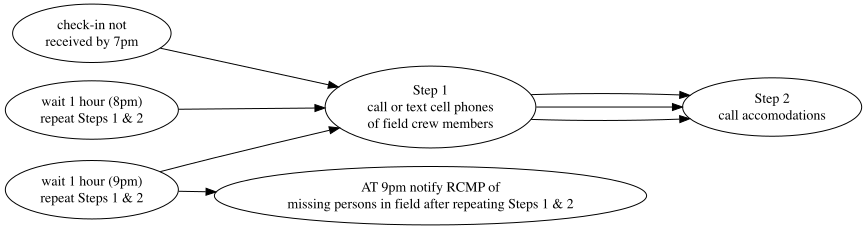

Figure 2: Procedures for failed check-in

[figure not shown]

Figure 3: Map of potential sampling areas.

Table 5: Potential Phase 1 assessment, Phase 2 assessment, and Electrofishing Locations

| id | stream_name | utm_zone | utm_easting | utm_northing | watershed_group_code | pscis_assessment_comment |
| --- | --- | --- | --- | --- | --- | --- |
| 125000 | tributary to Parsnip River | 10 | 577541 | 6038215 | PARS | High priority candidate for restoration. Good habitat. Surveyed upstream continuosly for 350 m to beaver influenced wetland area where walking became difficult. Then stream was visited again upstream … |
| 125179 | Unnamed tributary to Missinka River | 10 | 570307 | 6052836 | PARS | High priority candidate for restoration with habitat for rearing and overwintering upstream. Surveyed upstream for 520 m with no barriers to fish passage present. Bull trout and rainbow recorded upstr… |
| 125180 | tributary to Missinka River | 10 | 569664 | 6053048 | PARS | High priority candidate for restoration. Good habitat. Surveyed upstream of PSCIS crossing 125186 for a distance of 515 m. Good flow and abundant cover. Large woody debris and pools throughout. Freque… |
| 125231 | tributary to Table River | 10 | 549962 | 6065140 | PARS | High priority candidate for restoration. Good habitat. Surveyed for 600m to new bridge (modelled crossing 16603641). Some deep pools and bounlders, udercut banks, gravels throughout. Abundant large wo… |
| 125261 | Fern Creek | 10 | 534600 | 6067770 | PARS | Two additional culverts at 0.9m diameter. |
| 198667 | Tsatchuka Creek | 10 | 500641 | 6089777 | CARP | Grate on inlet and beaver influenced wetland upstream. Inlet blocked by beaver debris with beaver trap on inlet. Potentially good candidate for leveler to maintain beaver activity without attempting t… |
| 198668 | Tributary to McLeod Lake | 10 | 501971 | 6087814 | CARP | Abundant gravels, suitable for spawning upstream. Although flows are minimal, the streams does still have water. Models as having over 3 km of habitat upstream below 5%. Although no fish are recorded … |
| 198692 | Tributary to Kerry Lake | 10 | 511735 | 6059316 | CRKD | Nice little stream with decent flow for this time of year. Pockets of gravel throughout and healthy shrub and mixed riparian. Fish presence unknown, but seems likely due to proximity to Kerry lake wit… |

# References

BC Ministry of Environment. 2011. *Field Assessment for Determining Fish Passage Status of Closed Bottom Structures*. Manual. Victoria, British Columbia: BC Ministry of Environment. https://www2.gov.bc.ca/assets/gov/environment/natural-resource-stewardship/land-based-investment/forests-for-tomorrow/field-assessment-for-determining-fish-passage-status-of-cbs.pdf.

Fish Passage Technical Working Group. 2011. “A Checklist for Fish Habitat Confirmation Prior to the Rehabilitation Fo a Stream Crossing.” https://www2.gov.bc.ca/assets/gov/environment/natural-resource-stewardship/land-based-investment/forests-for-tomorrow/checklist-for-fish-habitat-confirmation-201112.pdf.

McPhail, J. D., and R Carveth. 1993. “Field Key to the Freshwater Fishes of British Columbia.” https://www2.gov.bc.ca/assets/gov/environment/natural-resource-stewardship/nr-laws-policy/risc/field_key_to_freshwater_fishes_of_bc_field_size_water_resistant_version.pdf.